# RNA-seq Differential Expression Analysis of Multiple Sclerosis White Matter Brain Lesions

ST2GEA - Genomics, Epigenetics and Applications Professor: MATHEW Mano Joseph

Author: Kiroshan SIVAKUMAR Student ID: 20221526

25/06/2026

# Introduction

Multiple sclerosis (MS) is a chronic inflammatory and neurodegenerative disease of the central nervous system (CNS) affecting approximately 2.8 million people worldwide. It is characterized by focal demyelination, axonal loss, and gliosis in white matter regions of the brain and spinal cord. The disease course is heterogeneous: lesions can be classified into distinct pathological stages including active, chronic active, inactive, and remyelinating, each reflecting different levels of inflammatory activity and tissue repair. Despite decades of research, the molecular mechanisms driving lesion development and progression remain incompletely understood, particularly at the transcriptomic level.

To investigate these mechanisms, [Elkjær et al. (2019)](https://pubmed.ncbi.nlm.nih.gov/31829262/) sequenced RNA from 73 white matter areas dissected from 10 progressive MS patients and 25 control donors without neurological disease. Using bulk RNA-seq, they identified 6 713 differentially expressed genes (FDR < 0.05) between MS tissue and control white matter. Their computational systems medicine analysis revealed lesion-type-specific molecular signatures and identified TGFbeta-R2, expressed by astrocytes, as a central hub in remyelination-associated protein networks. The raw count data generated by this study were deposited in the NCBI Gene Expression Omnibus under accession number [**GSE138614**](https://www.ncbi.nlm.nih.gov/geo/query/acc.cgi?acc=GSE138614), which is the dataset used in this project.

The main biological question is:

> **Which genes and biological pathways are differentially expressed in multiple sclerosis white matter brain lesions compared with control white matter brain tissue?**

This analysis follows a standard RNA-seq workflow. The first step covers raw count data import and quality assessment. The second step covers metadata preparation and DESeq2 differential expression modelling. The third step covers quality control visualizations including PCA and sample distance heatmap. The fourth step covers visualization of differentially expressed genes via volcano plot, MA plot, and heatmap. The fifth step covers functional enrichment analysis using Gene Ontology and KEGG pathways for both upregulated and downregulated gene sets. The sixth step covers comparison with the findings of the original publication.

# 1 - Setup

In this section, I load the required R packages, define a shared plot theme and color palette used consistently across all figures, and create output folders for saving results.

```r
# Install BiocManager if it is not already installed
if (!requireNamespace("BiocManager", quietly = TRUE)) {
  install.packages("BiocManager")
}

# List of required packages for the RNA-seq analysis
required_pkgs <- c(
  "DESeq2",
  "GEOquery",
  "org.Hs.eg.db",
  "AnnotationDbi",
  "clusterProfiler",
  "enrichplot",
  "ggplot2",
  "ggrepel",
  "pheatmap",
  "grid",
  "RColorBrewer",
  "dplyr",
  "tibble",
  "scales",
  "tidyr",
  "knitr",
  "kableExtra"
)

# Install missing packages automatically
for (pkg in required_pkgs) {
  if (!requireNamespace(pkg, quietly = TRUE)) {
    BiocManager::install(pkg, ask = FALSE)
  }
}
```

```
## Setting options('download.file.method.GEOquery'='auto')
```

```
## Setting options('GEOquery.inmemory.gpl'=FALSE)
```

```r
# Load libraries
suppressPackageStartupMessages({
  library(DESeq2)
  library(org.Hs.eg.db)
  library(AnnotationDbi)
  library(clusterProfiler)
  library(enrichplot)
  library(ggplot2)
  library(ggrepel)
  library(pheatmap)
  library(RColorBrewer)
  library(dplyr)
  library(tibble)
  library(scales)
  library(tidyr)
  library(knitr)
  library(kableExtra)
})

# Avoid conflicts between functions from different packages
select <- dplyr::select
filter <- dplyr::filter
rename <- dplyr::rename
mutate <- dplyr::mutate
arrange <- dplyr::arrange

# Publication-quality ggplot2 theme used for all figures in this analysis
theme_pub <- function(base_size = 13) {
  theme_bw(base_size = base_size) %+replace%
    theme(
      panel.grid.minor = element_blank(),
      panel.grid.major.x = element_blank(),
      panel.border = element_blank(),
      axis.line = element_line(color = "black", linewidth = 0.4),
      plot.title = element_text(face = "bold", size = base_size + 1,
                                hjust = 0, margin = margin(b = 6)),
      plot.subtitle = element_text(size = base_size - 1, color = "grey40",
                                   hjust = 0, margin = margin(b = 8)),
      legend.background = element_blank(),
      legend.key = element_blank(),
      strip.background = element_rect(fill = "grey92"),
      strip.text = element_text(face = "bold")
    )
}

# Shared color palette used consistently across all figures
COL_MS <- "#8B1A1A"
COL_CTRL <- "#2E6D9E"
COL_UP <- "#C0392B"
COL_DOWN <- "#2471A3"
COL_NS <- "grey75"

# Create output folders
dir.create("results", showWarnings = FALSE)
dir.create("results/figures", recursive = TRUE, showWarnings = FALSE)
dir.create("results/tables", recursive = TRUE, showWarnings = FALSE)
```

# 2 - Data Import and First Inspection

In this section, I import the raw count matrix and the human gene annotation file downloaded from GEO. Raw counts are required for DESeq2 because DESeq2 performs its own normalization internally and expects unmodified integer counts as input.

```r
# Load the raw count matrix downloaded from GEO
# Each row is a gene (NCBI GeneID), each column is a sample (GSM accession)
counts_raw <- read.delim(
  "data/GSE138614_raw_counts_GRCh38.p13_NCBI.tsv",
  check.names = FALSE
)

# Load the human gene annotation table from GEO supplementary files
gene_annot <- read.delim(
  "data/Human.GRCh38.p13.annot.tsv",
  check.names = FALSE
)

# Check dimensions of both files
cat("Count matrix dimensions (genes x samples):", dim(counts_raw), "\n")
```

```
## Count matrix dimensions (genes x samples): 39376 98
```

```r
cat("Annotation table dimensions (genes x columns):", dim(gene_annot), "\n")
```

```
## Annotation table dimensions (genes x columns): 39376 18
```

```r
# Preview the first rows and columns of the count matrix
cat("\nFirst rows of the count matrix:\n")
```

```
##
## First rows of the count matrix:
```

```r
head(counts_raw[, 1:6])
```

```
##      GeneID GSM4114296 GSM4114297 GSM4114298 GSM4114299 GSM4114300
## 1 100287102         17         19         27         22         15
## 2    653635        339        345        830        448        377
## 3 102466751         14         10         24          8          9
## 4 107985730          3          1          2          1          0
## 5 100302278          0          0          0          0          0
## 6    645520          1          7          2          2          4
```

```r
# Preview the annotation table
cat("\nFirst rows of the annotation table:\n")
```

```
##
## First rows of the annotation table:
```

```r
head(gene_annot[, 1:5])
```

```
##      GeneID      Symbol                                  Description
## 1 100287102     DDX11L1   DEAD/H-box helicase 11 like 1 (pseudogene)
## 2    653635      WASH7P            WASP family homolog 7, pseudogene
## 3 102466751   MIR6859-1                              microRNA 6859-1
## 4 107985730 MIR1302-2HG                          MIR1302-2 host gene
## 5 100302278   MIR1302-2                              microRNA 1302-2
## 6    645520     FAM138A family with sequence similarity 138 member A
##                    Synonyms GeneType
## 1                             pseudo
## 2             FAM39F|WASH5P   pseudo
## 3            hsa-mir-6859-1    ncRNA
## 4                              ncRNA
## 5 MIRN1302-2|hsa-mir-1302-2    ncRNA
## 6              F379|FAM138F    ncRNA
```

The raw count matrix contains 39 376 genes and 97 RNA-seq samples. Each row corresponds to a gene identified by its NCBI GeneID. The remaining columns contain raw read counts representing the number of sequencing reads mapped to each gene per sample.

The annotation table provides for each gene its NCBI GeneID, official symbol, full description, synonyms, and gene type. The first rows of the table contain pseudogenes and non-coding RNA genes such as DDX11L1 and WASH7P.

# 3 - Data Quality Assessment

Before performing differential expression analysis, it is important to check whether the raw count matrix contains technical problems. The main checks in RNA-seq analysis are missing values, duplicated gene identifiers, genes with zero counts across all samples, and the global distribution of counts across samples.

```r
# Check the total number of missing values in the count matrix
cat("Number of missing values:", sum(is.na(counts_raw)), "\n")
```

```
## Number of missing values: 0
```

```r
# Check whether any Gene IDs are duplicated
cat("Number of duplicated GeneIDs:", sum(duplicated(counts_raw$GeneID)), "\n")
```

```
## Number of duplicated GeneIDs: 0
```

```r
# Count genes with zero reads across all samples
zero_genes <- rowSums(counts_raw[, -1]) == 0
cat("Genes with zero counts across all samples:", sum(zero_genes), "\n")
```

```
## Genes with zero counts across all samples: 578
```

```r
# Percentage of zero-count genes
cat("Percentage of zero-count genes:", round(mean(zero_genes) * 100, 1), "%\n")
```

```
## Percentage of zero-count genes: 1.5 %
```

The count matrix contains no missing values and no duplicated GeneIDs, meaning each gene is represented exactly once and the matrix is complete.

578 genes show zero counts across all 97 samples, representing 1.5% of all genes. These genes are not expressed in this dataset and will be removed during the filtering step.

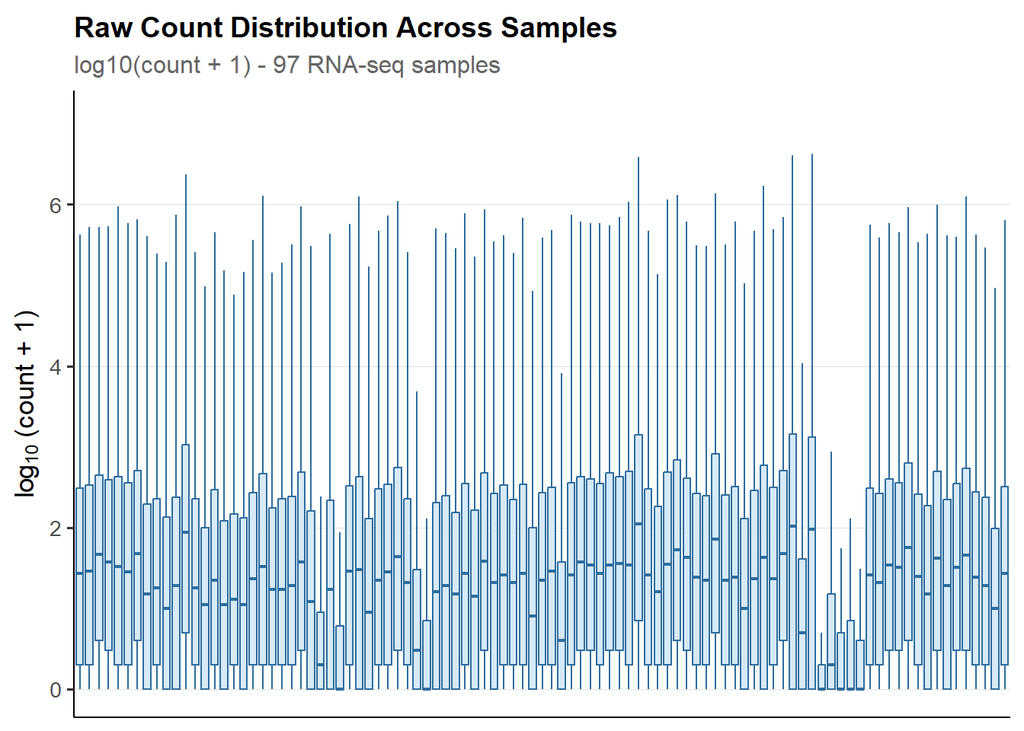

Figure 1 - Raw count distribution across all 97 samples (log10 scale).

```r
# Convert to long format for ggplot
raw_long <- as.data.frame(log10(counts_raw[, -1] + 1)) %>%
  pivot_longer(
    cols = everything(),
    names_to = "sample",
    values_to = "log10_count"
  )

ggplot(raw_long, aes(x = sample, y = log10_count)) +
  geom_boxplot(
    fill = "#D6EAF8",
    color = COL_CTRL,
    outlier.shape = NA,
    linewidth = 0.4
  ) +
  labs(
    title = "Raw Count Distribution Across Samples",
    subtitle = "log10(count + 1) - 97 RNA-seq samples",
    x = NULL,
    y = expression(log[10]~"(count + 1)")
  ) +
  theme_pub() +
  theme(
    axis.text.x = element_blank(),
    axis.ticks.x = element_blank(),
    panel.grid.major.y = element_line(color = "grey88", linewidth = 0.3)
  )
```

```r
ggsave(
  "results/figures/Figure1_Raw_counts_boxplot.png",
  width = 10,
  height = 5,
  dpi = 300,
  bg = "white"
)
```

The boxplot shows the distribution of raw read counts across all 97 samples after log10 transformation. Log10 transformation is applied here for visualization purposes only because raw RNA-seq counts span several orders of magnitude, from 0 to hundreds of thousands, which makes direct comparison between samples impossible to read on a linear scale. It does not modify the data used for downstream analysis, as DESeq2 always receives the original raw integer counts.

# 4 - Metadata Preparation

The count matrix contains only sample accession numbers as column names. To perform differential expression analysis, it is necessary to know which samples correspond to control white matter and which correspond to multiple sclerosis lesions. This information is retrieved from the GEO metadata associated with the dataset.

```r
if (!requireNamespace("GEOquery", quietly = TRUE)) {
  BiocManager::install("GEOquery", ask = FALSE)
}
library(GEOquery)

gse <- getGEO("GSE138614", GSEMatrix = TRUE)
```

```
## Found 1 file(s)
```

```
## GSE138614_series_matrix.txt.gz
```

```r
pheno <- pData(gse[[1]])
sample_names <- colnames(counts_raw)[-1]
pheno <- pheno[sample_names, ]

pheno[, grep("characteristics", colnames(pheno))] %>% head()
```

```
##                      characteristics_ch1 characteristics_ch1.1
## GSM4114296            diagnosis: Control         tissue: Brain
## GSM4114297 diagnosis: Multiple sclerosis         tissue: Brain
## GSM4114298 diagnosis: Multiple sclerosis         tissue: Brain
## GSM4114299 diagnosis: Multiple sclerosis         tissue: Brain
## GSM4114300 diagnosis: Multiple sclerosis         tissue: Brain
## GSM4114301 diagnosis: Multiple sclerosis         tissue: Brain
##                       characteristics_ch1.2 characteristics_ch1.3
## GSM4114296   lesion type: White matter (WM)        individual: C3
## GSM4114297 lesion type: Chronic active (CA)       individual: MS7
## GSM4114298 lesion type: Chronic active (CA)       individual: MS6
## GSM4114299 lesion type: Chronic active (CA)       individual: MS4
## GSM4114300 lesion type: Chronic active (CA)       individual: MS8
## GSM4114301 lesion type: Chronic active (CA)       individual: MS8
```

```r
pheno$condition <- ifelse(
  grepl("Control", pheno$characteristics_ch1),
  "Control",
  "MultipleSclerosis"
)

pheno$condition <- factor(
  pheno$condition,
  levels = c("Control", "MultipleSclerosis")
)

metadata <- data.frame(
  sample = rownames(pheno),
  condition = pheno$condition,
  row.names = rownames(pheno)
)

head(metadata)
```

```
##                sample         condition
## GSM4114296 GSM4114296           Control
## GSM4114297 GSM4114297 MultipleSclerosis
## GSM4114298 GSM4114298 MultipleSclerosis
## GSM4114299 GSM4114299 MultipleSclerosis
## GSM4114300 GSM4114300 MultipleSclerosis
## GSM4114301 GSM4114301 MultipleSclerosis
```

```r
table(metadata$condition)
```

```
##
##           Control MultipleSclerosis
##                25                72
```

```r
table(pheno$characteristics_ch1, metadata$condition)
```

```
##
##                                 Control MultipleSclerosis
##   diagnosis: Control                 25                 0
##   diagnosis: Multiple sclerosis       0                72
```

The GEO metadata contains four useful columns for each sample: diagnosis, tissue, lesion type, and individual donor identifier. All 97 samples come from brain tissue. The lesion type column reveals that the multiple sclerosis samples include different lesion categories such as chronic active, which confirms that the MS group is biologically heterogeneous.

The metadata table was created with two columns: the sample accession number and the biological condition. The dataset contains 25 control samples and 72 multiple sclerosis samples. The cross-tabulation confirms that the condition assignment is unambiguous: all 25 control samples correspond exclusively to diagnosis Control, and all 72 multiple sclerosis samples correspond exclusively to diagnosis Multiple sclerosis, with no misclassified samples.

Control is set as the reference level of the condition factor, meaning that a positive log2 fold change in the differential expression results will indicate higher expression in multiple sclerosis samples compared to control samples.

# 5 - Count Matrix Preparation

Before creating the DESeq2 dataset, the count matrix must be reformatted. The GeneID column is converted into row names because DESeq2 expects a matrix where genes are in rows and samples are in columns, with no extra identifier columns. It is also critical to verify that the sample order in the count matrix matches the sample order in the metadata table, as a mismatch would lead to incorrect condition assignments during differential expression analysis.

```r
# Assign GeneIDs as row names
rownames(counts_raw) <- counts_raw$GeneID

# Remove the GeneID column
counts_matrix <- as.matrix(counts_raw[, -1])

# Verify dimensions
cat("Count matrix dimensions (genes x samples):", dim(counts_matrix), "\n")
```

```
## Count matrix dimensions (genes x samples): 39376 97
```

```r
# Verify that sample order matches between matrix and metadata
cat("Sample order matches metadata:", all(colnames(counts_matrix) == rownames(metadata)), "\n")
```

```
## Sample order matches metadata: TRUE
```

The count matrix contains 39 376 genes and 97 samples after removing the GeneID column. The sample order verification confirms that the column names of the count matrix match the row names of the metadata table exactly, meaning each sample is correctly associated with its biological condition for downstream DESeq2 analysis.

# 6 - DESeq2 Dataset Creation and Filtering

The count matrix and the metadata table are combined into a DESeq2 dataset object. The experimental design is specified as a function of the condition variable, comparing multiple sclerosis samples against control samples. A filtering step is then applied to remove genes with very low counts, as these genes are not reliably expressed and would add noise to the statistical analysis without contributing meaningful signal.

```r
# Create DESeq2 dataset
dds <- DESeqDataSetFromMatrix(
  countData = counts_matrix,
  colData = metadata,
  design = ~ condition
)

# Display DESeq2 dataset information
cat("DESeq2 dataset dimensions before filtering:", dim(dds), "\n")
```

```
## DESeq2 dataset dimensions before filtering: 39376 97
```

```r
# Filter low-count genes: keep genes with at least 10 reads in at least 3 samples
keep_genes <- rowSums(counts(dds) >= 10) >= 3
dds <- dds[keep_genes, ]

cat("DESeq2 dataset dimensions after filtering:", dim(dds), "\n")
```

```
## DESeq2 dataset dimensions after filtering: 29913 97
```

```r
cat("Genes removed by filtering:", sum(!keep_genes), "\n")
```

```
## Genes removed by filtering: 9463
```

The DESeq2 dataset was created with 39 376 genes and 97 samples. After applying the filtering rule, which keeps only genes with at least 10 reads in at least 3 samples, 9 463 genes were removed and 29 913 genes were retained for differential expression analysis. The filtering rule ensures that only genes with a minimum level of expression across multiple samples are tested, which reduces noise and improves the statistical power of the analysis.

# 7 - Normalisation

Raw RNA-seq counts are affected by differences in sequencing depth between samples. A sample sequenced more deeply will have higher counts for all genes regardless of true biological differences. DESeq2 corrects for this by estimating size factors for each sample. To visualize the effect of this normalization, the count distributions before and after normalization are compared.

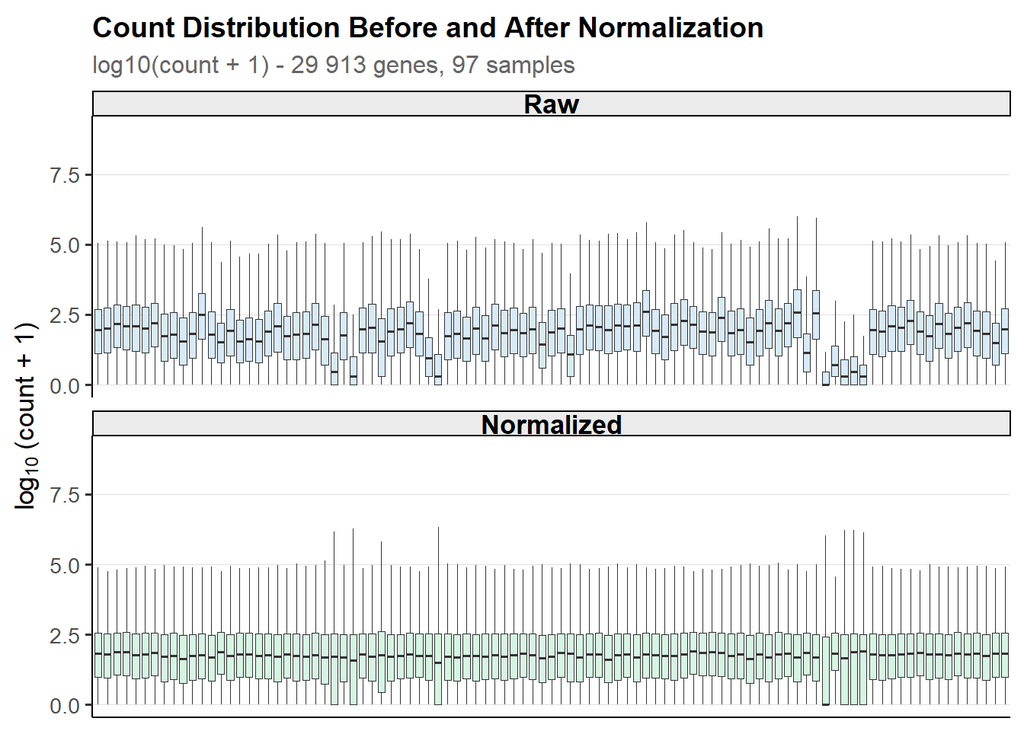

Figure 2 - Count distribution before and after DESeq2 size factor normalization (log10 scale).

```r
# Estimate size factors for normalization
dds <- estimateSizeFactors(dds)

# Extract raw and normalized counts
raw_counts <- counts(dds, normalized = FALSE)
norm_counts <- counts(dds, normalized = TRUE)

# Convert both to long format for ggplot
raw_df <- as.data.frame(log10(raw_counts + 1)) %>%
  pivot_longer(everything(), names_to = "sample", values_to = "log10_count") %>%
  mutate(type = "Raw")

norm_df <- as.data.frame(log10(norm_counts + 1)) %>%
  pivot_longer(everything(), names_to = "sample", values_to = "log10_count") %>%
  mutate(type = "Normalized")

plot_df <- bind_rows(raw_df, norm_df)
plot_df$type <- factor(plot_df$type, levels = c("Raw", "Normalized"))

ggplot(plot_df, aes(x = sample, y = log10_count, fill = type)) +
  geom_boxplot(outlier.shape = NA, linewidth = 0.3) +
  facet_wrap(~ type, ncol = 1) +
  scale_fill_manual(values = c(Raw = "#D6EAF8", Normalized = "#D5F5E3")) +
  labs(
    title = "Count Distribution Before and After Normalization",
    subtitle = "log10(count + 1) - 29 913 genes, 97 samples",
    x = NULL,
    y = expression(log[10]~"(count + 1)")
  ) +
  theme_pub() +
  theme(
    axis.text.x = element_blank(),
    axis.ticks.x = element_blank(),
    legend.position = "none",
    panel.grid.major.y = element_line(color = "grey88", linewidth = 0.3)
  )
```

```r
ggsave(
  "results/figures/Figure2_Normalisation.png",
  width = 10,
  height = 7,
  dpi = 300,
  bg = "white"
)
```

The two panels show the count distributions before and after DESeq2 size factor normalization. In the raw counts panel, the box heights and median positions vary noticeably between samples, reflecting differences in sequencing depth. Some samples show clearly lower medians, indicating that fewer total reads were sequenced for those samples.

After normalization, the median values and box heights are visibly more consistent across all 97 samples. This confirms that the size factor correction successfully accounts for sequencing depth differences between samples, ensuring that subsequent comparisons between conditions reflect true biological differences rather than technical variation.

# 8 - Differential Expression Analysis

DESeq2 is run to identify genes that are differentially expressed between multiple sclerosis lesion samples and control samples. The DESeq2 pipeline estimates gene-wise dispersions, fits a negative binomial model for each gene, and performs a Wald test to assess whether the expression difference between conditions is statistically significant. Results are extracted for the contrast multiple sclerosis versus control, and adjusted p-values are computed using the Benjamini-Hochberg method to control the false discovery rate.

```r
# Run the full DESeq2 pipeline
dds <- DESeq(dds)
```

```
## -- replacing outliers and refitting for 501 genes
## -- DESeq argument 'minReplicatesForReplace' = 7
## -- original counts are preserved in counts(dds)
```

```r
# Extract results for Multiple Sclerosis versus Control
res <- results(
  dds,
  contrast = c("condition", "MultipleSclerosis", "Control"),
  alpha = 0.05,
  pAdjustMethod = "BH"
)

# Summary of results
summary(res)
```

```
##
## out of 29913 with nonzero total read count
## adjusted p-value < 0.05
## LFC > 0 (up)       : 6374, 21%
## LFC < 0 (down)     : 4078, 14%
## outliers [1]       : 0, 0%
## low counts [2]     : 0, 0%
## (mean count < 0)
## [1] see 'cooksCutoff' argument of ?results
## [2] see 'independentFiltering' argument of ?results
```

```r
# Order results by adjusted p-value
res_ordered <- res[order(res$padj), ]

# Show the top 6 most significant genes
cat("\nTop 6 most significant genes:\n")
```

```
##
## Top 6 most significant genes:
```

```r
head(res_ordered)
```

```
## log2 fold change (MLE): condition MultipleSclerosis vs Control
## Wald test p-value: condition MultipleSclerosis vs Control
## DataFrame with 6 rows and 6 columns
##       baseMean log2FoldChange     lfcSE      stat      pvalue        padj
##      <numeric>      <numeric> <numeric> <numeric>   <numeric>   <numeric>
## 3500  4835.908        9.02921  0.470959   19.1720 6.34638e-82 1.89839e-77
## 3502   540.243       10.12663  0.571652   17.7147 3.22969e-70 4.83049e-66
## 3514  1931.138        8.15029  0.469038   17.3766 1.24024e-67 1.23664e-63
## 3501   760.799        9.10297  0.567661   16.0359 7.17052e-58 5.36230e-54
## 3538   426.570        9.92553  0.628668   15.7882 3.75188e-56 2.24460e-52
## 3505   215.153        9.13722  0.611750   14.9362 1.91609e-50 9.55268e-47
```

The DESeq2 pipeline ran successfully. Size factors estimated in the previous step were reused, and dispersion estimates were computed for all 29 913 genes. DESeq2 detected 501 genes with outlier counts and refitted the model for those genes using a robust procedure, while preserving the original counts.

Out of 29 913 genes tested, 6 374 genes are significantly upregulated in multiple sclerosis samples (21% of all tested genes) and 4 078 genes are significantly downregulated (14%), both at an adjusted p-value threshold of 0.05. No genes were flagged as outliers or removed due to low counts after filtering.

The six most significant genes show very large positive log2 fold changes, ranging from 8.2 to 10.1, and extremely small adjusted p-values below 10^-47. These genes are strongly overexpressed in multiple sclerosis samples compared to controls. The high fold changes suggest these genes are expressed at very low levels in control tissue and are strongly activated in MS lesions.

# 9 - Gene Annotation

The differential expression results currently use NCBI GeneIDs as row names. Gene symbols are added by merging the results with the annotation table loaded in section 2. A significance classification is also added to each gene based on its adjusted p-value and log2 fold change, which will be used for downstream visualizations.

```r
# Convert results to dataframe and remove rows with NA values
res_df <- as.data.frame(res)
res_df <- na.omit(res_df)
res_df$gene <- rownames(res_df)

# Keep only GeneID and Symbol columns from the annotation table
annot_subset <- gene_annot[, c("GeneID", "Symbol")]
annot_subset$GeneID <- as.character(annot_subset$GeneID)
res_df$gene <- as.character(res_df$gene)

# Merge DESeq2 results with gene symbols
res_annot <- merge(
  res_df,
  annot_subset,
  by.x = "gene",
  by.y = "GeneID",
  all.x = TRUE
)

# Use GeneID as fallback when symbol is missing
res_annot$Symbol[is.na(res_annot$Symbol)] <-
  res_annot$gene[is.na(res_annot$Symbol)]

# Add significance classification
res_annot$significance <- case_when(
  res_annot$padj < 0.05 & res_annot$log2FoldChange > 1 ~ "Upregulated",
  res_annot$padj < 0.05 & res_annot$log2FoldChange < -1 ~ "Downregulated",
  TRUE ~ "Not Significant"
)

# Display annotated results
cat("Total annotated genes:", nrow(res_annot), "\n")
```

```
## Total annotated genes: 29913
```

```r
cat("Upregulated:", sum(res_annot$significance == "Upregulated"), "\n")
```

```
## Upregulated: 2595
```

```r
cat("Downregulated:", sum(res_annot$significance == "Downregulated"), "\n")
```

```
## Downregulated: 508
```

```r
cat("Not Significant:", sum(res_annot$significance == "Not Significant"), "\n")
```

```
## Not Significant: 26810
```

```r
# Save annotated results table
write.csv(
  res_annot,
  "results/tables/deseq2_results_annotated.csv",
  row.names = FALSE
)
```

The DESeq2 results were successfully annotated with gene symbols for all 29 913 tested genes. Applying the stricter biological threshold of adjusted p-value below 0.05 and absolute log2 fold change above 1, 2 595 genes are classified as upregulated and 508 genes are classified as downregulated in multiple sclerosis samples compared to controls. The remaining 26 810 genes show no statistically significant or biologically meaningful difference in expression between the two conditions.

The annotated results table was saved to results/tables/deseq2_results_annotated.csv for reproducibility.

# 10 - Quality Control

## 10.1 - Dispersion Estimates

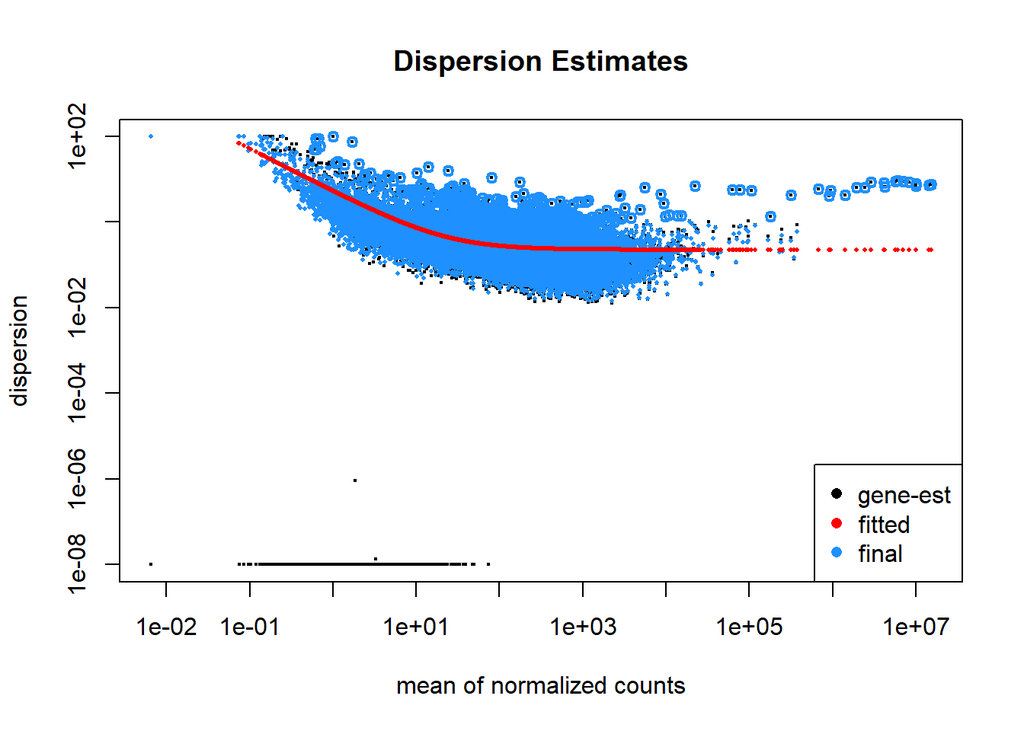

Figure 3 - DESeq2 dispersion estimates.

```r
# Plot dispersion estimates to assess model fit quality
plotDispEsts(
  dds,
  main = "Dispersion Estimates"
)
```

```r
# Save the figure
png(
  "results/figures/Figure3_Dispersion.png",
  width = 1500,
  height = 1000,
  res = 150,
  bg = "white"
)
plotDispEsts(dds, main = "Dispersion Estimates")
dev.off()
```

The dispersion plot shows three sets of values for each gene. The black dots are the gene-wise maximum likelihood dispersion estimates. The red line is the fitted mean-dispersion trend, which shows that dispersion decreases as mean expression increases, a pattern that is typical in RNA-seq data where lowly expressed genes tend to have higher variability. The blue dots are the final shrunken dispersion estimates, where each gene-wise estimate has been pulled towards the fitted trend line.

## 10.2 - Principal Component Analysis

Principal Component Analysis (PCA) is used to visualize the global similarity between samples after variance stabilizing transformation (VST). VST is applied instead of a simple log2 transformation because it accounts for the mean-variance relationship in RNA-seq data, producing more stable variance estimates across the range of expression levels. Samples with similar gene expression profiles cluster together in the PCA plot, while samples with different profiles are separated.

```r
# Apply variance stabilizing transformation
vsd <- vst(dds, blind = FALSE)

# Compute PCA
pca_data <- plotPCA(vsd, intgroup = "condition", returnData = TRUE)
```

```
## using ntop=500 top features by variance
```

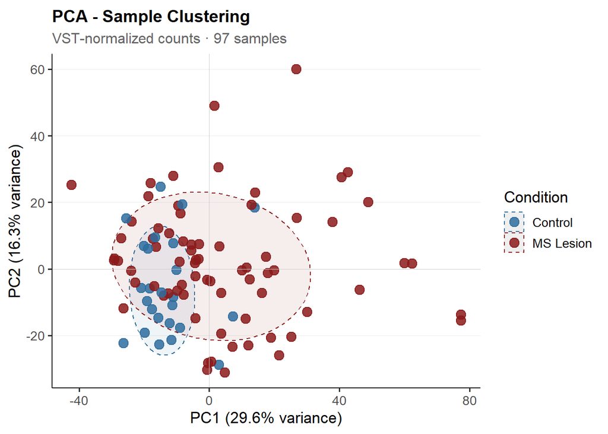

Figure 4 - PCA of RNA-seq samples after VST normalization.

```r
pct_var <- round(100 * attr(pca_data, "percentVar"), 1)

# Plot
ggplot(pca_data, aes(x = PC1, y = PC2, color = condition)) +
  stat_ellipse(
    aes(fill = condition),
    geom = "polygon",
    alpha = 0.08,
    level = 0.68,
    linetype = "dashed",
    linewidth = 0.4
  ) +
  geom_point(size = 3.5, alpha = 0.85) +
  geom_hline(yintercept = 0, color = "grey80", linewidth = 0.3) +
  geom_vline(xintercept = 0, color = "grey80", linewidth = 0.3) +
  scale_color_manual(
    values = c(Control = COL_CTRL, MultipleSclerosis = COL_MS),
    labels = c("Control", "MS Lesion")
  ) +
  scale_fill_manual(
    values = c(Control = COL_CTRL, MultipleSclerosis = COL_MS),
    guide = "none"
  ) +
  labs(
    title = "PCA - Sample Clustering",
    subtitle = "VST-normalized counts · 97 samples",
    x = paste0("PC1 (", pct_var[1], "% variance)"),
    y = paste0("PC2 (", pct_var[2], "% variance)"),
    color = "Condition"
  ) +
  theme_pub() +
  theme(
    panel.grid.major.y = element_line(color = "grey92", linewidth = 0.3)
  )
```

```r
ggsave(
  "results/figures/Figure4_PCA.png",
  width = 9,
  height = 7,
  dpi = 300,
  bg = "white"
)
```

PC1 explains 29.6% of the total variance and PC2 explains 16.3%. Together they capture 45.9% of the total variance in the dataset.

Control samples form a compact cluster on the left side of the plot, indicating that healthy white matter samples have relatively similar gene expression profiles. Multiple sclerosis samples are much more dispersed, spreading across a wide range of PC1 and PC2 values. Several MS samples are located far from the main cluster, particularly along the PC1 axis, suggesting that some lesions have a strongly distinct transcriptomic profile compared to others.

The two groups show partial separation along PC1, with MS samples tending towards higher PC1 values. However, there is considerable overlap between the two groups, particularly for MS samples that cluster close to the control region. This overlap is consistent with the fact that the MS group contains different lesion types at different pathological stages, some of which may be transcriptomically closer to control tissue than others.

## 10.3 - Sample Distance Heatmap

The sample distance heatmap shows the pairwise Euclidean distances between all 97 samples based on their VST-normalized expression profiles. Smaller distances indicate more similar transcriptomic profiles. This plot complements the PCA by showing the global structure of the dataset in a different way, without reducing the data to two principal components.

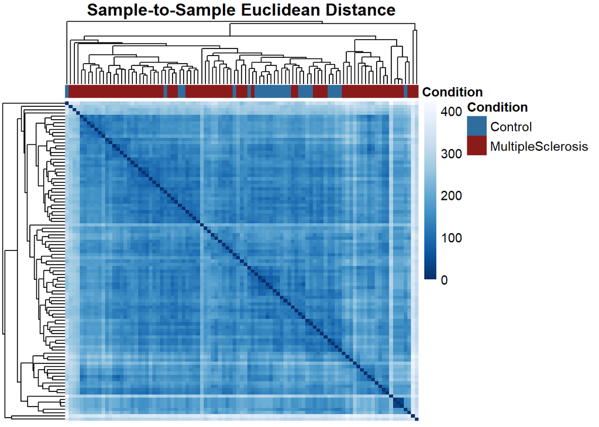

Figure 5 - Sample-to-sample distance heatmap.

```r
# Compute pairwise Euclidean distances
sample_dist <- dist(t(assay(vsd)))
sample_dist_matrix <- as.matrix(sample_dist)

# Create annotation for conditions
annotation_col <- data.frame(
  Condition = colData(vsd)$condition,
  row.names = colnames(vsd)
)

# Annotation colors
anno_colors <- list(
  Condition = c(Control = COL_CTRL, MultipleSclerosis = COL_MS)
)

# Color palette
dist_colors <- colorRampPalette(rev(brewer.pal(9, "Blues")))(100)

# Save figure
png(
  "results/figures/Figure5_Sample_distance.png",
  width = 1600,
  height = 1400,
  res = 150,
  bg = "white"
)
pheatmap(
  sample_dist_matrix,
  clustering_distance_rows = sample_dist,
  clustering_distance_cols = sample_dist,
  annotation_col = annotation_col,
  annotation_colors = anno_colors,
  col = dist_colors,
  show_rownames = FALSE,
  show_colnames = FALSE,
  main = "Sample-to-Sample Euclidean Distance",
  fontsize = 11,
  border_color = NA
)
```

```r
dev.off()
```

```r
# Display inline
pheatmap(
  sample_dist_matrix,
  clustering_distance_rows = sample_dist,
  clustering_distance_cols = sample_dist,
  annotation_col = annotation_col,
  annotation_colors = anno_colors,
  col = dist_colors,
  show_rownames = FALSE,
  show_colnames = FALSE,
  main = "Sample-to-Sample Euclidean Distance",
  fontsize = 11,
  border_color = NA
)
```

The heatmap shows the pairwise Euclidean distances between all 97 samples based on their VST-normalized expression profiles. Darker blue indicates smaller distances, meaning more similar transcriptomic profiles. Each sample has a distance of zero with itself, producing the dark diagonal line.

The heatmap also reveals that some MS samples cluster closer to control samples than to other MS samples, which is consistent with the PCA results and reflects the biological heterogeneity of MS lesions at different pathological stages.

# 11 - Visualisation of Differential Expression Results

## 11.1 - Volcano Plot

The volcano plot combines the statistical significance and the magnitude of expression change for all tested genes simultaneously. Each point represents one gene. Genes on the right side of the plot are more expressed in multiple sclerosis samples, while genes on the left side are more expressed in control samples. The vertical dashed lines indicate the log2 fold change threshold of 1 and -1, and the horizontal dashed line indicates the adjusted p-value threshold of 0.05.

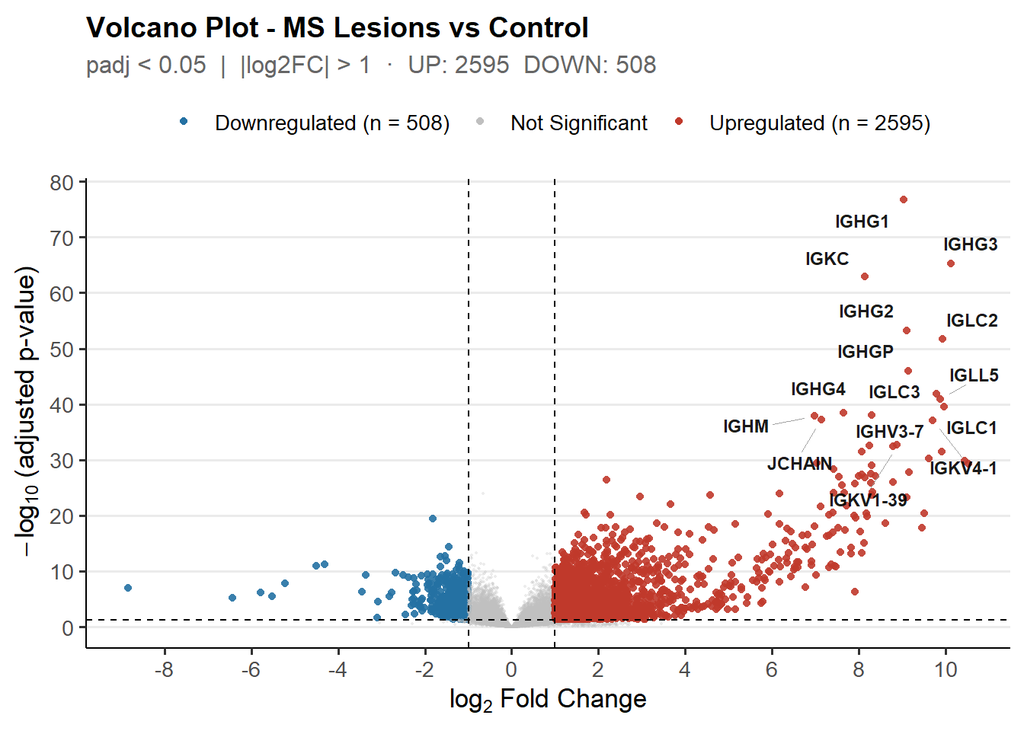

Figure 6 - Volcano plot of differential expression results.

```r
# Select top 15 most significant genes for labeling
top15 <- res_annot %>%
  filter(significance != "Not Significant") %>%
  arrange(padj) %>%
  head(15)

# Count per category
n_up <- sum(res_annot$significance == "Upregulated")
n_down <- sum(res_annot$significance == "Downregulated")

ggplot(
  res_annot %>% arrange(significance),
  aes(
    x = log2FoldChange,
    y = -log10(padj),
    color = significance,
    alpha = significance,
    size = significance
  )
) +
  geom_point(shape = 16, stroke = 0) +
  geom_hline(yintercept = -log10(0.05), linetype = "dashed",
             color = "black", linewidth = 0.4) +
  geom_vline(xintercept = c(-1, 1), linetype = "dashed",
             color = "black", linewidth = 0.4) +
  geom_text_repel(
    data = top15,
    aes(label = Symbol),
    size = 3,
    color = "black",
    fontface = "bold",
    box.padding = 0.4,
    point.padding = 0.3,
    max.overlaps = 25,
    segment.color = "grey60",
    segment.size = 0.3
  ) +
  scale_color_manual(
    values = c(
      Upregulated = COL_UP,
      Downregulated = COL_DOWN,
      "Not Significant" = COL_NS
    ),
    labels = c(
      Downregulated = paste0("Downregulated (n = ", n_down, ")"),
      "Not Significant" = "Not Significant",
      Upregulated = paste0("Upregulated (n = ", n_up, ")")
    ),
    name = NULL
  ) +
  scale_alpha_manual(
    values = c(Upregulated = 0.9, Downregulated = 0.9, "Not Significant" = 0.3),
    guide = "none"
  ) +
  scale_size_manual(
    values = c(Upregulated = 1.8, Downregulated = 1.8, "Not Significant" = 0.7),
    guide = "none"
  ) +
  scale_x_continuous(breaks = scales::pretty_breaks(n = 8)) +
  scale_y_continuous(breaks = scales::pretty_breaks(n = 8)) +
  labs(
    title = "Volcano Plot - MS Lesions vs Control",
    subtitle = paste0("padj < 0.05  |  |log2FC| > 1  ·  UP: ", n_up, "  DOWN: ", n_down),
    x = expression(log[2]~"Fold Change"),
    y = expression(-log[10]~"(adjusted p-value)")
  ) +
  theme_pub() +
  theme(legend.position = "top")
```

```r
ggsave(
  "results/figures/Figure6_Volcano.png",
  width = 10,
  height = 8,
  dpi = 300,
  bg = "white"
)
```

The volcano plot shows that 2 595 genes are significantly upregulated and 508 genes are significantly downregulated in multiple sclerosis lesions compared to controls, using a threshold of adjusted p-value below 0.05 and absolute log2 fold change above 1. The remaining 26 810 genes show no significant differential expression.

The most significant genes are located in the upper right corner of the plot, combining both high statistical significance and large positive fold changes. All 15 labeled genes belong to immunoglobulin families, including IGHG1, IGHG2, IGHG3, IGHG4, IGHGP, IGKC, IGKV1-39, IGKV4-1, IGLC1, IGLC2, IGLC3, IGLL5, IGHM, IGHV3-7, and JCHAIN. These genes encode immunoglobulin heavy chains, light chains, and joining chains, which are produced by plasma cells and B cells during antibody-mediated immune responses.

The plot also shows a clear asymmetry between upregulated and downregulated genes. There are considerably more strongly upregulated genes than downregulated genes, suggesting that the dominant transcriptomic change in MS lesions is activation of biological processes rather than their suppression.

## 11.2 - MA Plot

The MA plot shows the relationship between the mean normalized expression of each gene and its log2 fold change between multiple sclerosis and control samples. It is complementary to the volcano plot: while the volcano plot highlights statistical significance on the y axis, the MA plot shows whether fold changes are dependent on expression level, which can reveal potential biases in the data.

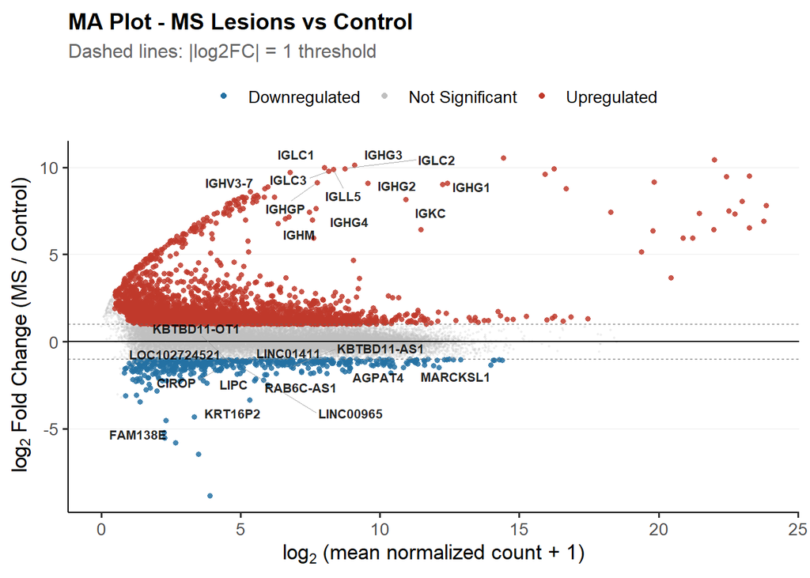

Figure 7 - MA plot of differential expression results.

```r
# Select top 12 genes per direction for labeling
top_label <- bind_rows(
  res_annot %>% filter(significance == "Upregulated") %>% arrange(padj) %>% head(12),
  res_annot %>% filter(significance == "Downregulated") %>% arrange(padj) %>% head(12)
)

ggplot(
  res_annot %>% arrange(significance),
  aes(
    x = log2(baseMean + 1),
    y = log2FoldChange,
    color = significance,
    alpha = significance,
    size = significance
  )
) +
  geom_point(shape = 16, stroke = 0) +
  geom_hline(yintercept = 0, color = "black", linewidth = 0.5) +
  geom_hline(yintercept = c(-1, 1), color = "grey40", linewidth = 0.35,
             linetype = "dashed") +
  geom_text_repel(
    data = top_label,
    aes(label = Symbol),
    size = 2.8,
    color = "black",
    fontface = "bold",
    max.overlaps = 20,
    box.padding = 0.35,
    segment.color = "grey60",
    segment.size = 0.25
  ) +
  scale_color_manual(
    values = c(
      Upregulated = COL_UP,
      Downregulated = COL_DOWN,
      "Not Significant" = COL_NS
    ),
    labels = c(
      Downregulated = "Downregulated",
      "Not Significant" = "Not Significant",
      Upregulated = "Upregulated"
    ),
    name = NULL
  ) +
  scale_alpha_manual(
    values = c(Upregulated = 0.85, Downregulated = 0.85, "Not Significant" = 0.25),
    guide = "none"
  ) +
  scale_size_manual(
    values = c(Upregulated = 1.6, Downregulated = 1.6, "Not Significant" = 0.7),
    guide = "none"
  ) +
  labs(
    title = "MA Plot - MS Lesions vs Control",
    subtitle = "Dashed lines: |log2FC| = 1 threshold",
    x = expression(log[2]~"(mean normalized count + 1)"),
    y = expression(log[2]~"Fold Change (MS / Control)")
  ) +
  theme_pub() +
  theme(
    legend.position = "top",
    panel.grid.major.y = element_line(color = "grey92", linewidth = 0.3)
  )
```

```r
ggsave(
  "results/figures/Figure7_MA_plot.png",
  width = 10,
  height = 7,
  dpi = 300,
  bg = "white"
)
```

The MA plot shows that differentially expressed genes are distributed across all expression levels, from lowly to highly expressed genes. The upregulated genes form a dense cloud above the log2 fold change threshold of 1, spread across the full range of mean expression values. The most strongly upregulated genes at moderate expression levels include immunoglobulin genes such as IGLC1, IGLC2, IGLC3, IGHG1, IGHG2, IGHG3, IGKC, and IGHM, consistent with the volcano plot results.

The plot does not show a strong systematic bias where fold changes increase or decrease with expression level, suggesting that the DESeq2 normalization adequately corrected for sequencing depth differences between samples.

## 11.3 - Heatmap of Top Differentially Expressed Genes

The heatmap displays the expression patterns of the most significant differentially expressed genes across all 97 samples. The top 25 upregulated and top 25 downregulated genes are shown separately, selected by adjusted p-value. Expression values are VST-normalized and scaled by row to produce z-scores, allowing comparison of relative expression patterns across samples regardless of absolute expression levels.

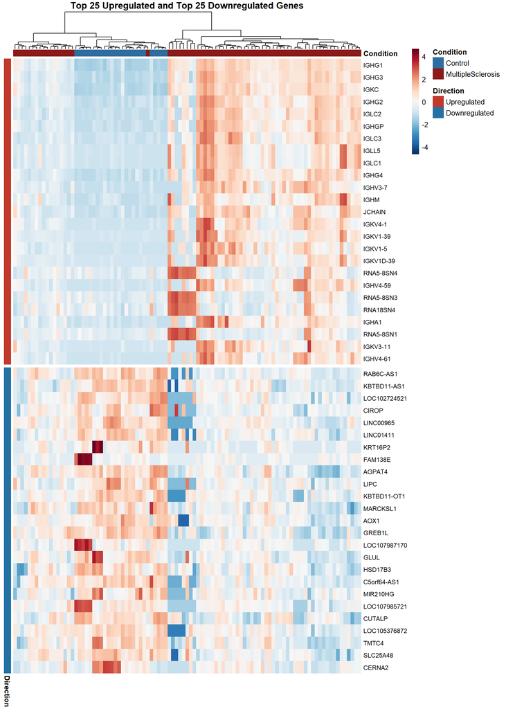

Figure 8 - Heatmap of top 25 upregulated and top 25 downregulated genes.

```r
# Select top 25 upregulated genes by adjusted p-value
top25_up <- res_annot %>%
  filter(significance == "Upregulated") %>%
  arrange(padj) %>%
  head(25) %>%
  pull(gene)

# Select top 25 downregulated genes by adjusted p-value
top25_down <- res_annot %>%
  filter(significance == "Downregulated") %>%
  arrange(padj) %>%
  head(25) %>%
  pull(gene)

# Combine both gene lists
top50_genes <- c(top25_up, top25_down)

# Extract VST expression matrix
vsd_mat <- assay(vsd)
heatmap_mat <- vsd_mat[top50_genes, ]

# Replace GeneIDs with gene symbols
gene_symbols <- annot_subset$Symbol[match(top50_genes, annot_subset$GeneID)]
gene_symbols[is.na(gene_symbols)] <- top50_genes[is.na(gene_symbols)]
rownames(heatmap_mat) <- make.unique(gene_symbols)

# Column annotation
annotation_col <- data.frame(
  Condition = metadata$condition,
  row.names = rownames(metadata)
)

# Row annotation to distinguish UP from DOWN
annotation_row <- data.frame(
  Direction = c(rep("Upregulated", 25), rep("Downregulated", 25)),
  row.names = rownames(heatmap_mat)
)

# Colors
anno_colors <- list(
  Condition = c(Control = COL_CTRL, MultipleSclerosis = COL_MS),
  Direction = c(Upregulated = COL_UP, Downregulated = COL_DOWN)
)
ht_colors <- colorRampPalette(rev(brewer.pal(11, "RdBu")))(100)

# Save figure
png(
  "results/figures/Figure8_Heatmap.png",
  width = 2400,
  height = 2800,
  res = 200,
  bg = "white"
)
pheatmap(
  heatmap_mat,
  scale = "row",
  annotation_col = annotation_col,
  annotation_row = annotation_row,
  annotation_colors = anno_colors,
  show_rownames = TRUE,
  show_colnames = FALSE,
  cluster_rows = FALSE,
  clustering_distance_cols = "euclidean",
  clustering_method = "ward.D2",
  gaps_row = 25,
  fontsize_row = 9,
  color = ht_colors,
  border_color = NA,
  main = "Top 25 Upregulated and Top 25 Downregulated Genes"
)
```

```r
dev.off()
```

```r
# Display inline
pheatmap(
  heatmap_mat,
  scale = "row",
  annotation_col = annotation_col,
  annotation_row = annotation_row,
  annotation_colors = anno_colors,
  show_rownames = TRUE,
  show_colnames = FALSE,
  cluster_rows = FALSE,
  clustering_distance_cols = "euclidean",
  clustering_method = "ward.D2",
  gaps_row = 25,
  fontsize_row = 9,
  color = ht_colors,
  border_color = NA,
  main = "Top 25 Upregulated and Top 25 Downregulated Genes"
)
```

The heatmap displays the top 25 upregulated and top 25 downregulated genes across all 97 samples, with a gap separating the two groups. Expression values are row-scaled as z-scores, so red indicates relatively high expression and blue indicates relatively low expression for each gene.

The upregulated genes show a clear pattern: most multiple sclerosis samples display high expression of immunoglobulin genes including IGHG1, IGHG2, IGHG3, IGKC, IGLC1, IGLC2, IGLC3, IGHM, and several IGKV and IGHV family members, while control samples show consistently low expression of these genes. The hierarchical clustering of samples separates most control samples into a distinct cluster on the left, confirming the transcriptomic difference between the two conditions.

The downregulated genes show a less consistent pattern across MS samples. Genes such as RAB6C-AS1, KBTBD11-AS1, CIROP, LINC00965, and LINC01411 tend to show lower expression in MS samples compared to controls, but the signal is weaker and more variable than for the upregulated genes. Several downregulated genes are long non-coding RNAs and antisense transcripts, suggesting that regulatory non-coding RNA expression is also altered in MS lesions.

# 12 - Functional Enrichment Analysis

## 12.1 - GO Biological Process - Upregulated Genes

Gene Ontology enrichment analysis identifies biological processes that are overrepresented among the differentially expressed genes compared to all tested genes. This analysis is performed separately for upregulated and downregulated genes to distinguish between activated and suppressed biological processes in multiple sclerosis lesions.

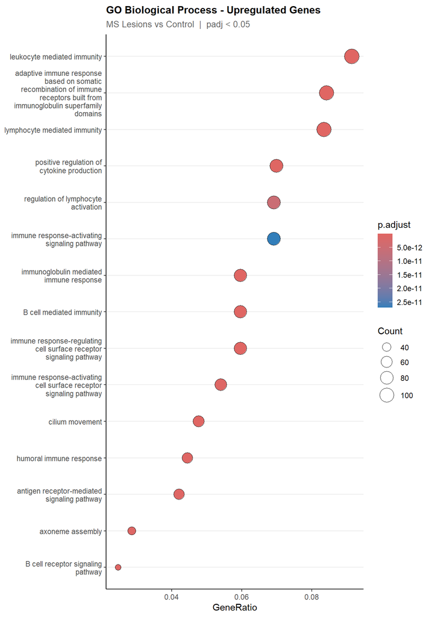

Figure 9 - GO Biological Process enrichment for upregulated genes.

```r
# Prepare gene lists
genes_up <- unique(res_annot$gene[res_annot$significance == "Upregulated"])
genes_down <- unique(res_annot$gene[res_annot$significance == "Downregulated"])
universe_genes <- unique(res_annot$gene)

# GO enrichment on upregulated genes
ego_up <- enrichGO(
  gene = genes_up,
  universe = universe_genes,
  OrgDb = org.Hs.eg.db,
  keyType = "ENTREZID",
  ont = "BP",
  pAdjustMethod = "BH",
  pvalueCutoff = 0.05,
  qvalueCutoff = 0.20,
  readable = TRUE
)

# Display dotplot
dotplot(ego_up, showCategory = 15, font.size = 10) +
  labs(
    title = "GO Biological Process - Upregulated Genes",
    subtitle = "MS Lesions vs Control  |  padj < 0.05"
  ) +
  theme_pub(base_size = 11)
```

```r
ggsave(
  "results/figures/Figure9_GO_UP.png",
  width = 11,
  height = 9,
  dpi = 300,
  bg = "white"
)

# Export results
write.csv(
  as.data.frame(ego_up),
  "results/tables/GO_UP_enrichment.csv",
  row.names = FALSE
)
```

The GO Biological Process enrichment analysis for upregulated genes reveals strong and consistent enrichment of immune-related processes in multiple sclerosis lesions. The most significantly enriched terms with the highest gene ratios are leukocyte mediated immunity, lymphocyte mediated immunity, and adaptive immune response based on somatic recombination of immune receptors built from immunoglobulin superfamily domains. These three terms have the largest dot sizes, indicating that they are supported by the highest number of genes among all enriched terms.

Other significantly enriched terms include positive regulation of cytokine production, regulation of lymphocyte activation, immunoglobulin mediated immune response, B cell mediated immunity, immune response-activating signaling pathway, and B cell receptor signaling pathway. Together these terms describe a coordinated activation of both innate and adaptive immune responses involving B cells, lymphocytes, and cytokine signaling.

Overall, the GO enrichment results are consistent with the volcano plot and heatmap findings, where immunoglobulin genes dominated the list of most significantly upregulated genes.

## 12.2 - GO Biological Process - Downregulated Genes

The same GO enrichment analysis is performed on the downregulated genes to identify biological processes that are suppressed in multiple sclerosis lesions compared to control white matter tissue.

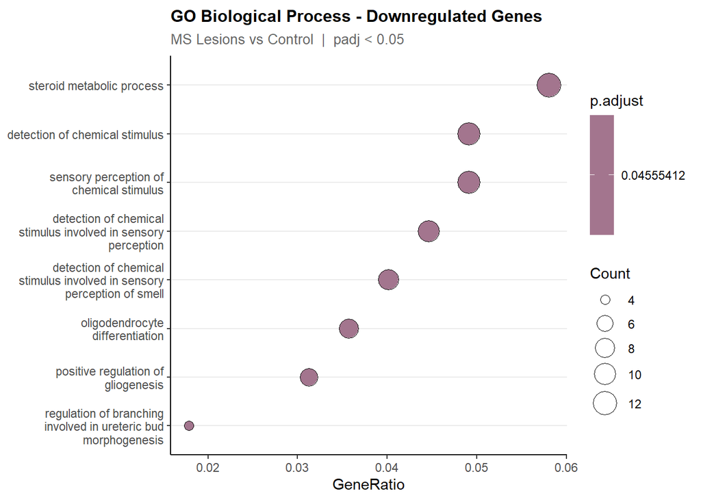

Figure 10 - GO Biological Process enrichment for downregulated genes.

```r
# GO enrichment on downregulated genes
ego_down <- enrichGO(
  gene = genes_down,
  universe = universe_genes,
  OrgDb = org.Hs.eg.db,
  keyType = "ENTREZID",
  ont = "BP",
  pAdjustMethod = "BH",
  pvalueCutoff = 0.05,
  qvalueCutoff = 0.20,
  readable = TRUE
)

# Check if enrichment produced results
if (!is.null(ego_down) && nrow(ego_down@result) > 0) {
  p <- dotplot(ego_down, showCategory = 15, font.size = 10) +
    labs(
      title = "GO Biological Process - Downregulated Genes",
      subtitle = "MS Lesions vs Control  |  padj < 0.05"
    ) +
    theme_pub(base_size = 11)

  print(p)

  ggsave(
    "results/figures/Figure10_GO_DOWN.png",
    plot = p,
    width = 11,
    height = 9,
    dpi = 300,
    bg = "white"
  )

  write.csv(
    as.data.frame(ego_down),
    "results/tables/GO_DOWN_enrichment.csv",
    row.names = FALSE
  )
} else {
  cat("No significant GO terms found for downregulated genes.\n")
}
```

The GO Biological Process enrichment analysis for downregulated genes reveals a different biological signature compared to the upregulated genes. Only 8 significant terms were identified, reflecting the smaller number of downregulated genes in this dataset.

The most enriched term by gene ratio is steroid metabolic process, supported by the largest number of genes among all enriched terms. This suggests that steroid metabolism is reduced in MS lesions compared to control white matter tissue.

Several terms related to sensory perception and chemical stimulus detection are also enriched, including detection of chemical stimulus, sensory perception of chemical stimulus, and detection of chemical stimulus involved in sensory perception of smell. These terms likely reflect the presence of olfactory receptor genes among the downregulated genes, which are known to be expressed outside the olfactory system in various tissues.

Two terms directly relevant to central nervous system biology are also enriched: oligodendrocyte differentiation and positive regulation of gliogenesis. The downregulation of oligodendrocyte differentiation is particularly relevant in the context of multiple sclerosis, as oligodendrocytes are the myelin-producing cells of the central nervous system. Their reduced differentiation in MS lesions is consistent with the known loss of myelin and failure of remyelination in progressive multiple sclerosis.

## 12.3 - KEGG Pathway Enrichment

KEGG pathway enrichment analysis identifies molecular signaling pathways that are overrepresented among the differentially expressed genes. This analysis is performed separately for upregulated and downregulated genes.

```r
# KEGG enrichment on upregulated genes
ekegg_up <- enrichKEGG(
  gene = genes_up,
  universe = universe_genes,
  organism = "hsa",
  keyType = "ncbi-geneid",
  pvalueCutoff = 0.05,
  pAdjustMethod = "BH"
)
```

```
## Reading KEGG annotation online: "https://rest.kegg.jp/link/hsa/pathway"...
```

```
## Reading KEGG annotation online: "https://rest.kegg.jp/list/pathway/hsa"...
```

```
## Reading KEGG annotation online: "https://rest.kegg.jp/conv/ncbi-geneid/hsa"...
```

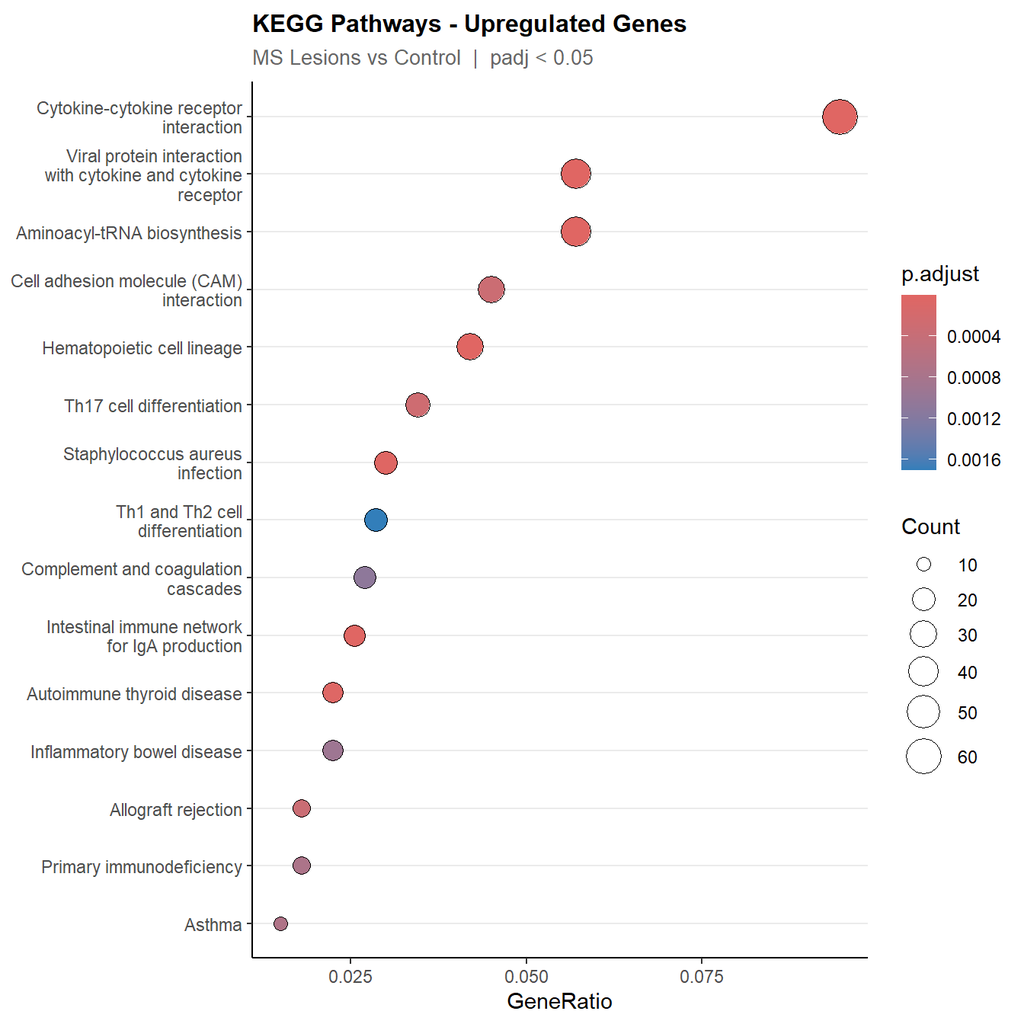

```r
ekegg_up <- setReadable(ekegg_up, OrgDb = org.Hs.eg.db, keyType = "ENTREZID")

p_kegg_up <- dotplot(ekegg_up, showCategory = 15, font.size = 10) +
  labs(
    title = "KEGG Pathways - Upregulated Genes",
    subtitle = "MS Lesions vs Control  |  padj < 0.05"
  ) +
  theme_pub(base_size = 11)

print(p_kegg_up)
```

[figure not shown]

Figure 11 - KEGG pathway enrichment for upregulated and downregulated genes.

```r
ggsave(
  "results/figures/Figure11a_KEGG_UP.png",
  plot = p_kegg_up,
  width = 11,
  height = 9,
  dpi = 300,
  bg = "white"
)

write.csv(
  as.data.frame(ekegg_up),
  "results/tables/KEGG_UP_enrichment.csv",
  row.names = FALSE
)

# KEGG enrichment on downregulated genes
ekegg_down <- enrichKEGG(
  gene = genes_down,
  universe = universe_genes,
  organism = "hsa",
  keyType = "ncbi-geneid",
  pvalueCutoff = 0.05,
  pAdjustMethod = "BH"
)

if (!is.null(ekegg_down) && nrow(ekegg_down@result) > 0) {
  ekegg_down <- setReadable(ekegg_down, OrgDb = org.Hs.eg.db, keyType = "ENTREZID")

  p_kegg_down <- dotplot(ekegg_down, showCategory = 15, font.size = 10) +
    labs(
      title = "KEGG Pathways - Downregulated Genes",
      subtitle = "MS Lesions vs Control  |  padj < 0.05"
    ) +
    theme_pub(base_size = 11)

  print(p_kegg_down)

  ggsave(
    "results/figures/Figure11b_KEGG_DOWN.png",
    plot = p_kegg_down,
    width = 11,
    height = 9,
    dpi = 300,
    bg = "white"
  )

  write.csv(
    as.data.frame(ekegg_down),
    "results/tables/KEGG_DOWN_enrichment.csv",
    row.names = FALSE
  )
} else {
  cat("No significant KEGG pathways found for downregulated genes.\n")
}
```

The KEGG pathway enrichment analysis for upregulated genes identifies 15 significant pathways. The most enriched pathway by gene ratio is cytokine-cytokine receptor interaction, supported by the largest number of genes among all pathways. This reflects the extensive cytokine signaling activity associated with immune cell infiltration in MS lesions.

Other significantly enriched pathways include viral protein interaction with cytokine and cytokine receptor, hematopoietic cell lineage, Th17 cell differentiation, Th1 and Th2 cell differentiation, complement and coagulation cascades, and intestinal immune network for IgA production. The enrichment of T cell differentiation pathways, including Th1, Th2, and Th17, confirms the involvement of multiple T cell subtypes in MS lesion pathology. The complement and coagulation cascades pathway suggests activation of innate immune mechanisms in addition to the adaptive immune response.

Several pathways associated with other inflammatory and autoimmune diseases are also enriched, including autoimmune thyroid disease, inflammatory bowel disease, allograft rejection, and asthma. These pathways share common immune dysregulation mechanisms with multiple sclerosis, involving similar immune cell populations and signaling molecules.

## 12.4 - Gene-Concept Network

The gene-concept network connects enriched GO terms to their individual member genes, allowing visualization of which specific genes drive the enrichment of each biological process. This plot is shown for the upregulated genes only, as they produced the most significant and biologically interpretable enrichment results.

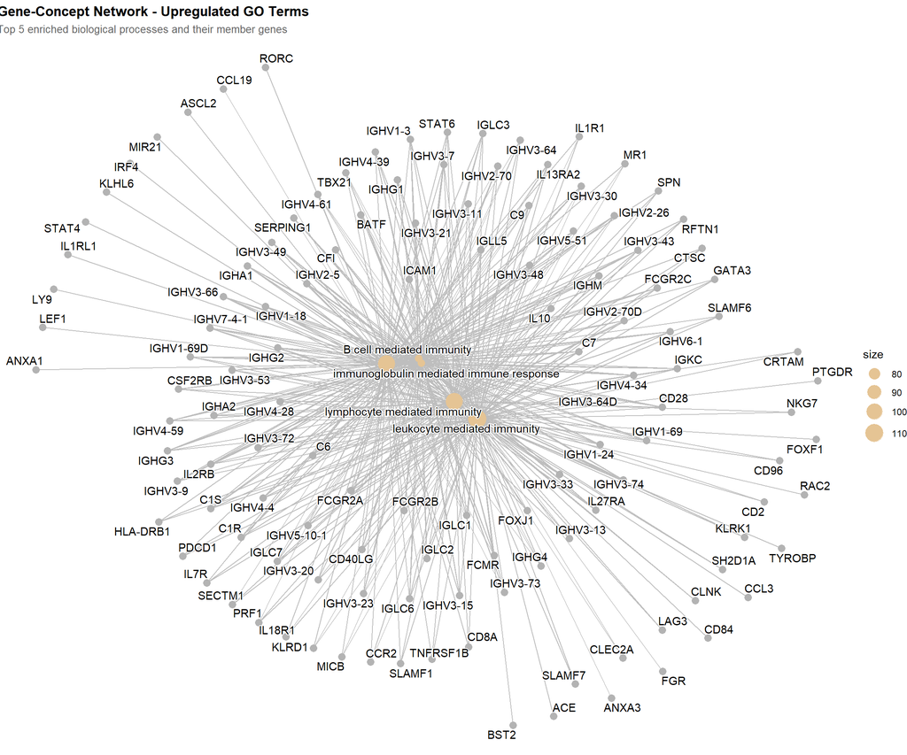

Figure 12 - Gene-concept network for upregulated GO terms.

```r
# Gene-concept network for top 5 GO terms
p_cnet <- cnetplot(
  ego_up,
  showCategory = 5
) +
  labs(
    title = "Gene-Concept Network - Upregulated GO Terms",
    subtitle = "Top 5 enriched biological processes and their member genes"
  ) +
  theme(
    plot.title = element_text(face = "bold", size = 13, hjust = 0),
    plot.subtitle = element_text(size = 10, color = "grey40", hjust = 0)
  )

print(p_cnet)
```

```r
ggsave(
  "results/figures/Figure12_Cnetplot.png",
  plot = p_cnet,
  width = 14,
  height = 10,
  dpi = 300,
  bg = "white"
)
```

The gene-concept network connects the top 5 enriched GO biological processes to their individual member genes. The four central nodes represent leukocyte mediated immunity, lymphocyte mediated immunity, immunoglobulin mediated immune response, and B cell mediated immunity. These terms are heavily interconnected, meaning that many genes contribute to multiple processes simultaneously.

The high degree of connectivity between the four central GO terms and the large number of member genes confirms that immune activation in MS lesions is driven by a broad and coordinated transcriptomic response rather than a small number of isolated genes.

# 13 - Comparison with the Original Publication

The dataset used in this analysis was generated by Elkjær et al. (2019), who published the original study in Acta Neuropathologica Communications. This section compares the results obtained in this analysis with the findings reported in the original publication to assess consistency and to identify differences arising from methodological choices.

```r
comparison_df <- data.frame(
  Aspect = c(
    "Samples used",
    "Control samples",
    "MS samples",
    "Genes detected",
    "Genes tested after filtering",
    "DEGs at FDR < 0.05",
    "Upregulated (|log2FC| > 1)",
    "Downregulated (|log2FC| > 1)",
    "Alignment tool",
    "Count tool",
    "Statistical model",
    "Multiple testing correction",
    "Lesion types compared",
    "Central hub gene identified"
  ),
  This_Analysis = c(
    "97",
    "25",
    "72",
    "39 376",
    "29 913",
    "10 452",
    "2 595",
    "508",
    "Pre-computed counts from GEO",
    "Pre-computed counts from GEO",
    "DESeq2 ~ condition (Wald test)",
    "Benjamini-Hochberg",
    "All MS lesions pooled vs Control",
    "Not identified"
  ),
  Elkjaer_2019 = c(
    "98",
    "25",
    "73",
    "18 609",
    "18 609",
    "6 713",
    "750",
    "206",
    "STAR v2.6 - hg38",
    "HTSeq-count v0.10.0",
    "DESeq2 (lesion-type models)",
    "Benjamini-Hochberg",
    "5 lesion types vs Control",
    "TGFbeta-R2 (astrocytic hub)"
  )
)

kable(
  comparison_df,
  col.names = c("Aspect", "This Analysis", "Elkjaer et al. 2019"),
  caption = "Table 1 - Comparison between this analysis and the original publication"
) %>%
  kable_styling(
    bootstrap_options = c("striped", "hover", "bordered"),
    full_width = TRUE
  )
```

Table 1 - Comparison between this analysis and the original publication

| Aspect | This Analysis | Elkjaer et al. 2019 |
| --- | --- | --- |
| Samples used | 97 | 98 |
| Control samples | 25 | 25 |
| MS samples | 72 | 73 |
| Genes detected | 39 376 | 18 609 |
| Genes tested after filtering | 29 913 | 18 609 |
| DEGs at FDR < 0.05 | 10 452 | 6 713 |
| Upregulated (&#124;log2FC&#124; > 1) | 2 595 | 750 |
| Downregulated (&#124;log2FC&#124; > 1) | 508 | 206 |
| Alignment tool | Pre-computed counts from GEO | STAR v2.6 - hg38 |
| Count tool | Pre-computed counts from GEO | HTSeq-count v0.10.0 |
| Statistical model | DESeq2 ~ condition (Wald test) | DESeq2 (lesion-type models) |
| Multiple testing correction | Benjamini-Hochberg | Benjamini-Hochberg |
| Lesion types compared | All MS lesions pooled vs Control | 5 lesion types vs Control |
| Central hub gene identified | Not identified | TGFbeta-R2 (astrocytic hub) |

The comparison table highlights both similarities and differences between this analysis and the original publication.

The sample counts are nearly identical: this analysis uses 97 samples with 25 controls and 72 MS samples, while the original study used 98 samples with 25 controls and 73 MS samples. The small difference of one sample in the MS group likely reflects a sample that was excluded during preprocessing in one of the two analyses.

The most notable difference is in the number of genes detected. The original study detected 18 609 genes while this analysis detected 39 376 genes. This difference arises from the use of different genome annotations and counting pipelines. The original study used STAR alignment and HTSeq-count on hg38, while this analysis uses pre-computed counts from GEO based on the GRCh38.p13 annotation, which includes a larger number of gene entries including pseudogenes and non-coding RNA genes.

The number of DEGs also differs considerably. This analysis identifies 10 452 significant genes at FDR below 0.05, compared to 6 713 in the original study. With the stricter threshold of absolute log2 fold change above 1, this analysis finds 2 595 upregulated and 508 downregulated genes, compared to 750 and 206 in the original publication. The higher counts in this analysis are partly explained by the larger number of tested genes and by the use of a single binary contrast that pools all MS lesion types together, which increases statistical power to detect the dominant immune signal but loses the lesion-type specificity of the original study.

The original publication performed five separate comparisons for each lesion type versus control, which allowed identification of TGFbeta-R2 as a hub gene specifically enriched in remyelinating lesions. This level of detail is not captured in this analysis because all MS samples are grouped into a single condition.

Despite these methodological differences, both analyses consistently identify immune activation as the dominant transcriptomic signal in MS lesions, with enrichment of immunoglobulin genes, B cell and T cell pathways, and cytokine signaling, confirming the biological validity of the results.

# Conclusion

This analysis investigated the transcriptomic changes associated with multiple sclerosis white matter brain lesions using RNA-seq differential expression analysis on the publicly available dataset GSE138614.

After importing raw counts from 97 samples, performing quality assessment, and filtering low-count genes, 29 913 genes were retained for DESeq2 differential expression analysis. The normalization step confirmed that sequencing depth differences between samples were successfully corrected. The PCA and sample distance heatmap showed that control samples form a compact and homogeneous cluster, while multiple sclerosis samples are more dispersed, reflecting the biological heterogeneity of lesions at different pathological stages.

Differential expression analysis identified 10 452 significantly dysregulated genes at an adjusted p-value below 0.05. Applying a stricter biological threshold of absolute log2 fold change above 1, 2 595 genes were classified as strongly upregulated and 508 genes as strongly downregulated in multiple sclerosis lesions compared to controls.

The volcano plot, MA plot, and heatmap consistently showed that the most significantly upregulated genes belong to immunoglobulin families, including IGHG1, IGHG2, IGHG3, IGKC, IGLC1, IGLC2, and IGLC3, reflecting strong B cell and plasma cell infiltration in MS lesions.

The gene-concept network confirmed that the immune activation signal is driven by a broad coordinated response involving hundreds of genes across multiple interconnected biological processes.

Comparison with the original publication by Elkjær et al. (2019) showed consistent biological findings despite methodological differences. Both analyses identify immune activation as the dominant transcriptomic signal. The higher DEG counts in this analysis reflect the use of a binary contrast pooling all lesion types, which increases statistical power but loses the lesion-type specificity demonstrated in the original study.

A limitation of this analysis is that all multiple sclerosis lesion types were grouped into a single condition. Future work could stratify samples by lesion type to identify lesion-specific molecular signatures, as performed in the original publication.

# Appendix - Reproducibility

This analysis was written as a single R Markdown document to ensure full reproducibility. All steps from data import to functional enrichment are contained in a single file that can be re-executed from start to finish. All figures are saved automatically in the results/figures folder and all tables are saved in the results/tables folder.

```r
cat("Figures generated:\n")
```

```
## Figures generated:
```

```r
list.files("results/figures")
```

```
##  [1] "Figure1_Raw_counts_boxplot.png" "Figure10_GO_DOWN.png"
##  [3] "Figure11a_KEGG_UP.png"          "Figure11b_KEGG_DOWN.png"
##  [5] "Figure12_Cnetplot.png"          "Figure2_Normalisation.png"
##  [7] "Figure3_Dispersion.png"         "Figure4_PCA.png"
##  [9] "Figure5_Sample_distance.png"    "Figure6_Volcano.png"
## [11] "Figure7_MA_plot.png"            "Figure8_Heatmap.png"
## [13] "Figure9_GO_UP.png"
```

```r
cat("\nTables generated:\n")
```

```
##
## Tables generated:
```

```r
list.files("results/tables")
```

```
## [1] "deseq2_results_annotated.csv" "GO_DOWN_enrichment.csv"
## [3] "GO_UP_enrichment.csv"         "KEGG_DOWN_enrichment.csv"
## [5] "KEGG_UP_enrichment.csv"
```